# Dribbling Through the Lifecycle

Getting to know the data science lifecycle with NBA data.

Written by: Jennifer Grant

[figure not shown]

I graduated from UC Berkeley in May of 2020 with an undergraduate degree in Applied  
Mathematics. What an interesting time to be sent off into the world - during a global  
pandemic! One lesson I’ve discovered early on in post-graduation is that having a degree  
opens doors, but whether or not you’re chosen to step through one is dependent upon the projects you take up.

Projects **outside of classwork** provide an opportunity to show potential employers that you are interested in their work and have put thought into their business problems/research questions. I go out of my way to bold **outside of classwork** because you’d chuckle if you were to compare your resume with peers - you all write about the exact same class projects! Luckily, with data science, working on your own solo (or not) project is easier than ever before because of the abundance of quality data online.

I know, I know - where do you even begin when working on a solo project!? I worked on a data science project this summer that I hope can give future employers a glimpse at my curiosity around working with data. I share my experience working through the data science lifecycle with you so that you can see how easy it is to use tools and content from class to expand your portfolio and prep for a post-graduation world.

#### Project Introduction

Before Berkeley I lived in San Diego for 6 years and got to experience what I call “football frenzy”. I don’t know much about football and at the time I didn’t make much of an effort to learn, so I’m trying to turn a new leaf in northern California by diving into the dominant sports culuture here - basketball.

Basketball is so embedded in the Bay Area culture that if you take any data science class at UC Berkeley, you’ll almost certainly work with/talk about NBA datasets. So, after my junior year at Berkeley I knew that I needed to drink the NBA kool-aide so-to-speak, and this project is an extension of my kool-aide-drinking epiphany. I’ll be working with NBA data spanning ten seasons (2009-2019) and focus on answering hypothesis questions about how team salary relates to team performance. The questions I’m asking in this project are:

1. Do teams with high salaries tend to win more games?
2. Do teams with younger, less experiences players tend to have lower salaries?
3. How have team salaries changed over the last ten seasons? Very rapidly? Remained somewhat constant? Increased? Decreased?

I share my code and personal experience working through the data science lifecycle, from data aquisition to data cleaning to data exploration to published visualizations online. I used R’s Shiny App to publish my visualizations and highly recommend the package as it’s easy to use. I also have a video [here](https://youtu.be/hsHwMV5i2gM) you can watch that introduces my project, my data source, my Shiny App code, and my final published visualizations.

Strap in and let’s begin!

#### Data Prep

In my opinion, there are two main stages in prepping data: acquiring & cleaning for future analysis. I used to think that acquiring data from online sources was a bit scary, but once you do it a couple times you start to become more comfortable with the process. I do my best in this project to explain and show my code for each step so as to provide more guidance.

###### Data Acquisition

The challenge around any data project is finding your data source. Sometimes this part will actually dictate what kind of project you end up choosing. Luckily, with sports, there is a plethora of sources for game/team data. All of my data comes from [Basketball Reference](https://www.basketball-reference.com/), a great source for any team-related statistics and data.

Once you know where the data will come from, the next step is usually figuring out how to ingest that data, whether through scraping a webpage directly or by downloading some sort of data file like a csv file (**c**omma **s**eparated **v**alues). It’s during this step that you need to reflect on how to keep your data files **organized**! This may seem irrelevent for small projects, and I’ve definitely gotten away without doing so, but once you start working on more complex projects you tend to learn fast that keeping your files organized is imperative for your sanity.

Below I’m sharing a rough diagram of how I usually choose to keep my files organized for a larger project, so feel free to use the same schematic in yours!

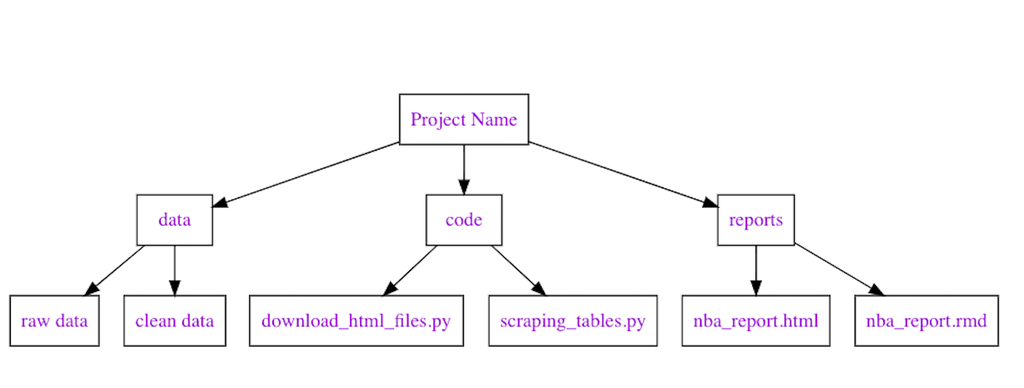

My chosen file structure.

Before I talk about how I acquired my data for the project, let’s quickly talk about Hypertext Markup Language (HTML) files. HTML is the language used in documents that makeup a webpage. Since I’m working with online data (and maybe you too), it’s important to get comfortable with how data is formatted online. Figure 1 below shows a snapshot of an HTML file for the Toronto Raptors’ homepage on Basketball Reference. If you want to look at a webpage’s html file on a Mac, just hold control as you click anywhere on the page and select *View Page Source*. With a quick google search you can find the same operation for Windows.

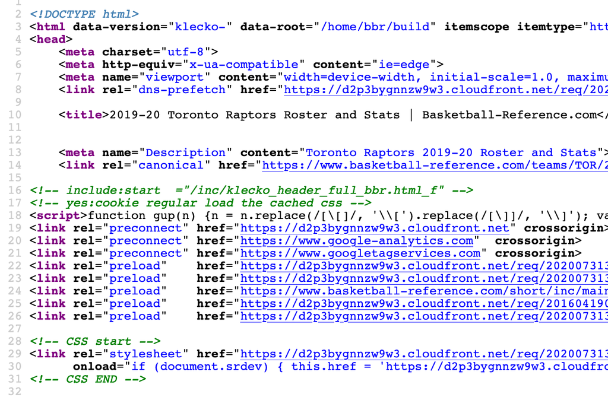

Figure 1 - Example HTML page from Basketball Reference under Toronto Raptors team statistics

For my project, I decided to downloaded the HTML files that make up each team’s homepage on the Basketball Reference website, and saved them on my local laptop. I decided to do this because I knew I would need data from multiple tables on each team’s homepage and didn’t want to overwhelm the website with data requests (yes, you can crash a website for sending too many requests, which can come along with legal trouble!!).

Downloading HTML pages from the web is quite easy! It’s about finding the common pattern between each url. Can you see the pattern from the sample urls below?

https://www.basketball-reference.com/teams/TOR/2010.html  
https://www.basketball-reference.com/teams/ATL/2011.html  
https://www.basketball-reference.com/teams/GSW/2012.html

They’re basically the same, except for the team abbreviation and season at the end - easy for-loop material!

If you’re not familiar with R base utilities, I use both directory methods *dir.exist* and *dir.create* to first check whether a folder already exists on my local laptop (dir=directory=folder) before creating it, and then use *download.file* to download the html file to a folder on my laptop (destfile). I share all of my code below so that you can do this with your own project. It really doesn’t have to be that scary!

```r
# common url
basketref <- 'https://www.basketball-reference.com'

# 30 NBA team abbreviations
team_names <- c(
  'ATL', 'BOS', 'BRK', 'CHI', 'CHO', 'CLE', 'DAL', 'DEN', 'DET', 'GSW',
  'HOU', 'IND', 'LAC', 'LAL', 'MEM', 'MIA', 'MIL', 'MIN', 'NOP', 'NYK',
  'OKC', 'ORL', 'PHI', 'PHO', 'POR', 'SAC', 'SAS', 'TOR', 'UTA', 'WAS'
)

# number of teams - need for loop
num_teams <- length(team_names)

# vector of seasons - need for loop
seasons <- 2010:2019


# downloading html documents into subdirectory 'rawdata/html-files/year'
for (year in seasons) {

  # make sure subdirectory for each season exists and if not yet, create it
  subdir <- paste0("rawdata/html-files/", year)
  if (!dir.exists(subdir)) {
    dir.create(subdir)
  }

  for (team in 1:num_teams) {

    # below's sequence of if-statements account for name changes among certain
    # teams during seasons 2009-2019
    if (year <= 2012 & team_names[team] == 'BRK') {
      print(paste('downloading html file for NJN (former BRK)',
                  year))
      url_doc <- paste0(basketref, '/teams/NJN/', year, '.html')
    } else if (year <= 2014 & team_names[team] == 'CHO') {
      print(paste('downloading html file for CHA (former CHO)',
                  year))
      url_doc <- paste0(basketref, '/teams/CHA/', year, '.html')
    } else if (year <= 2013 & team_names[team] == 'NOP') {
      print(paste('downloading html file for NOH (former NOP)',
                  year))
      url_doc <- paste0(basketref, '/teams/NOH/', year, '.html')
    } else {
      print(paste('downloading html file for', team_names[team],
                  'season', year))
      url_doc <- paste0(basketref, '/teams/', team_names[team],
                        '/', year, '.html')
    }

    # download
    download.file(
      url = url_doc,
      destfile = paste0('rawdata/html-files/', year, '/',
                        team_names[team], '-', year, '.html'))
  } # end looping through teams in season

} # end looping through all seasons
```

You’ll notice a sequence of if-statements in the code above that’s accounting for team name changes. Well, something cool I learnt during the downloading process is that Jay-Z is a minority owner of the Brooklyn Nets (BKN), and that they used to play in New Jersey under the name The New Jersey Nets (NJN). I don’t know why, but I feel much cooler for knowing this.

Alright, now that downloading is complete, onto extracting the data - or “scraping”!

Personally, scraping an HTML file or a webpage directly can be overwhelming at first because of the sheer amount of lines of code involved. The only way to be comfortable with this process is to understand the HTML structure. I found [this](https://www.w3schools.com/html/html_intro.asp) resource especially helpful. There is a menu bar on the left side that lists all of the possible components of an HTML file, like how to create and store information in an HTML table.

For my project I need to scrape the following tables:

- Roster table to get player names and their experience
- Misc table for team wins and losses
- Totals table for total points scored
- Salaries table for each team’s total salary.

Since I know the exact tables, I can parse through the HTML file and find the id of the node containing my tables. Here’s a picture showing the table node for the Roster table if you’re interested:

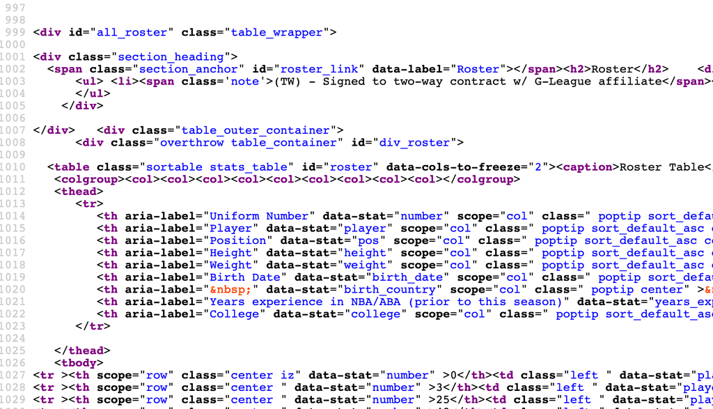

Figure 2 - Roster table for Toronto in html format

There are a couple different libraries in R that you can use to scrape through an html file. I use the XML library so that I can access the *readHTMLtable* function. Read the documentation for this method [here](https://cran.r-project.org/web/packages/XML/XML.pdf) - use the menu on the left to scroll to readHTMLtable. This function enables me to extract table data from the html files and store it into a dataframe. Once we have a dataframe, it’s easy to save the data as a csv file for future analysis.

```r
#load our needed library
library(XML)

# make sure subdirectories exist inside 'rawdata/'- if not, create them
data_dirs <- c("roster", "totals", "salary", "team_misc")

for (d in data_dirs) {
  subdir <- paste0("rawdata/", d)
  if (!dir.exists(subdir)) {
    dir.create(subdir)
  }
}


# name abbrevitions of 30 NBA teams
team_names <- c(
  'ATL', 'BOS', 'BRK', 'CHI', 'CHO', 'CLE', 'DAL', 'DEN', 'DET', 'GSW',
  'HOU', 'IND', 'LAC', 'LAL', 'MEM', 'MIA', 'MIL', 'MIN', 'NOP', 'NYK',
  'OKC', 'ORL', 'PHI', 'PHO', 'POR', 'SAC', 'SAS', 'TOR', 'UTA', 'WAS'
)

seasons <- 2010:2019


# extract html tables Roster, Totals, Salaries, and Misc for each season
for (year in seasons) {

  # make sure year folder exist inside subdirectories - if not create it
  for (d in data_dirs) {
    subdir <- paste0("rawdata/", d, '/', year)
    if (!dir.exists(subdir)) {
      dir.create(subdir)
    }
  }

  # vector to hold name of team html files for this season
  html_files <- paste0(team_names, '-', year, '.html')

  # loop through each team for this season
  for (team in 1:length(team_names)) {
    # Read html document (as a character vector) for a given team
    print(paste('scraping data for', team_names[team],
                'season', year))
    html_doc <- readLines(paste0('rawdata/html-files/',
                                 year, '/', html_files[team]))

    # ====================================================
    # Scrape Roster table
    # ====================================================
    # initial line position of roster html table
    begin_roster <- grep('id="roster"', html_doc)
    # find the line where the html ends
    line_counter <- begin_roster
    while (!grepl("</table>", html_doc[line_counter])) {
      line_counter <- line_counter + 1
    }
    # read in table as data.frame and export it as csv
    roster_tbl <- readHTMLTable(html_doc[begin_roster:line_counter])
    roster_csv <- paste0(team_names[team], '-', year, '-roster.csv')
    write.csv(roster_tbl,
              file = paste0('rawdata/roster/', year,
                            '/', roster_csv))

    # ====================================================
    # Scrape Totals table
    # ====================================================
    # initial line position of totals html table
    begin_totals <- grep('id="totals"', html_doc)
    # find the line where the html ends
    line_counter <- begin_totals
    while (!grepl("</table>", html_doc[line_counter])) {
      line_counter <- line_counter + 1
    }
    # read in table as data.frame and export it as csv
    totals_tbl <- readHTMLTable(html_doc[begin_totals:line_counter])
    totals_csv <- paste0(team_names[team], '-', year, '-totals.csv')
    write.csv(totals_tbl,
              file = paste0('rawdata/totals/', year,
                            '/', totals_csv))

    # ====================================================
    # Scrape Salaries table
    # ====================================================
    # initial line position of salaries html table
    begin_salaries <- grep('id="salaries2"', html_doc)
    # find the line where the html ends
    line_counter <- begin_salaries
    while (!grepl("</table>", html_doc[line_counter])) {
      line_counter <- line_counter + 1
    }
    # read in table as data.frame and export it as csv
    salaries_tbl <- readHTMLTable(html_doc[begin_salaries:line_counter])
    salaries_csv <- paste0(team_names[team], '-', year, '-salaries.csv')
    write.csv(salaries_tbl,
              file = paste0('rawdata/salary/', year,
                            '/', salaries_csv))

    # ====================================================
    # Scrape Misc table
    # ====================================================
    # initial line position of roster html table
    begin_misc <- grep('id="team_misc"', html_doc)
    # find the line where the html ends
    line_counter <- begin_misc
    while (!grepl("</table>", html_doc[line_counter])) {
      line_counter <- line_counter + 1
    }
    # read in table as data.frame and export it as csv
    misc_tbl <- readHTMLTable(html_doc[begin_misc:line_counter])
    misc_csv <- paste0(team_names[team], '-', year, '-misc.csv')
    write.csv(misc_tbl,
              file = paste0('../data/rawdata/team_misc/', year,
                            '/', misc_csv))
  } # end looping through teams

} # end loopinng through seasons
```

Now that I have all my data (yay!), I can start merging the columns I need from each table into a larger dataframe. I’ll show you how I also clean the data at the same time. Once we are done cleaning we can get to the fun part - exploring!

###### Data Cleaning

This is the last part of the data prep stage, and usually the least enjoyable for most. This is where I will need to merge relevent columns from all of my tables and make some changes to the data so that I can generate plots later.

I actually enjoy this part of the lifecycle because it feels like a fun puzzle - I know what the outcome must be (e.g. tables merged, dates cleaned, names changed to lowercase, convert datatype, etc) and it’s a creative process to get there. I’m lucky (or maybe unlucky?) in that there isn’t much actual data cleaning to do here, so you’ll see that I make the necessary changes (cleaning) when I merge features from different tables into one final, clean detaframe.

To make this whole process seamless under one big code chunk, I always first test out what I want to do with each table (grab column and clean data in column) using just one team as a simpler case, and then generalize up from there to all teams. I find that breaking up a task where I’ll eventually need to iterate through a large list/vector of objects (team, seasons, etc) helps with the debugging process. I’m also better able to visualize how to generalize my code (similar to what we did in figuring out the pattern in team URLs earlier). I’ll show you what I mean by starting with the Roster table. Below are the columns in the roster table:

```
##  [1] "index"      "No."        "Player"     "Position"   "Height"
##  [6] "Weight"     "Birthdate"  "Country"    "Experience" "College"
```

To answer my hypothesis questions I’m going to need the “Experience” column. I’m also going to grab the number of players on each team in case I want to compute averages.

It’s during this merging process that I notcied the Roster table and the Salaries table have different players on them for each team. The Roster table has more players, with some not on the Salaries table. Since my project is concentrated around team salaries, I decide to only include players that are present on the Salaries table. So, before I can grab the experience column, I’ll need to filter out players from the Roster table that are not on the Salaries table. I can’t stop here though, because notice the datatype and entries in the experience column:

```
##  [1] "11" "8"  "9"  "6"  "2"  "1"  "8"  "3"  "6"  "14" "5"  "R"  "2"  "4"
```

Notice the entries are all characters (strings) and a rookie player with “zero” experience is coded as ‘R’ for Rookie. I want to sum up team experience, so I’ll have to convert each entry to a numeric value using R’s *as.numeric* function, but first I’ll have to replace the “R” with “0”. Doing this is actually quite easy.

There are a couple ways to manipulate strings in R but I like to work with the stringr library. The functions in stringr are easy to remember because they are named really appropriately. Since I want to do a replacement of ‘R’ with ‘0’, I use stringr’s *str_replace_all* function. Once this change has been made, we can then convert all entries to a numeric data type instead of a string.

You’ll notice in my code below that after grabbing the experience column and cleaning it, I save it into a larger vector that will eventually hold every team’s summed experience for when I generalize up. Note that I also import the dplyr library so that I can use some of its dataframe manipulation functions, like *select*.

```r
# we'll need both the dplyr and strinr libraries (stringr for cleaning strings:))
library(dplyr)
library(stringr)

#set column names
col_names <- c('index', 'No.', 'Player', 'Position', 'Height', 'Weight',
              'Birthdate', 'Country', 'Experience', 'College')

# initialize a vector to hold each team's summed experience
total_team_experience <- c()

#going to also grab number of players, in case we want to compute averages
num_players <- c()

#import roster data as a csv file
roster <- read.csv('../data/rawdata/roster/2010/ATL-2010-roster.csv',
                  stringsAsFactors = FALSE,
                  col.names=col_names)

#import salary data as a csv file
sal_col_names <- c('Index', 'Rank','Player', 'Salary')
salary_players <- read.csv('../data/rawdata/salary/2010/ATL-2010-salaries.csv',
                  stringsAsFactors=FALSE,
                  col.names=sal_col_names)$Player

#consider only the experience of those on the salary table
roster <- roster[roster$Player %in% salary_players, ]

# from this table we only want to extract the experience column
experience <- select(roster, 'Experience')

# we are going to eventually need the combined experience for each team, so we
# replace all Rookie (R) entries with 0 and then convert the entire column to a
# numeric datatype
experience$Experience <- as.numeric(str_replace_all(experience$Experience, 'R', '0'))

# append the sum of Atlanta's experience column to a larger vector planned to
# hold all teams total experience; also append num of players to larger vector
total_team_experience <- c(total_team_experience, sum(experience$Experience))
num_players <- c(num_players, nrow(roster))
```

Sweet, we are done working with a simple case on the Roster table!

To provide more guidance, I’ll walk you through how I grabbed team salaries from the Salaries table, and then quickly show you the code for the last two tables.

Here are the columns from the Salaries table:

```
## [1] "Index"  "Rank"   "Player" "Salary"
```

I’m only going to need the total salary for each team (“Salary”), but notice again the dataype and special characters in the Salary column:

```
##  [1] "$14,976,754" "$10,800,000" "$9,360,000"  "$7,500,000"  "$6,217,617"
##  [6] "$4,750,000"  "$4,307,640"  "$2,500,000"  "$1,373,880"  "$1,306,455"
## [11] "$1,181,803"  "$855,189"    "$446,740"    "$307,564"
```

We are again dealing with numbers that should be numeric datatypes, but they’ve been stored as strings with special characters ($ and ,). Stringr has another handy dandy function called *str_remove_all* that lets you pick a pattern to be removed from a string. I used a regex pattern for this so that I can eliminate both the dollar sign and the comma in one go (see code for regex pattern). Once the special characters are removed I can again use R’s *as.numeric* to convert to a numeric datatype. Check out my code for this below.

```r
#set column names
col_names <- c('Index', 'Rank','Player', 'Salary')

#initialize vectors to hold all the teams total salaries, as well as min & max in case I need it
salaries <- c()
salaries_min <- c()
salaries_max <- c()

#import data as a csv file
salary <- read.csv('../data/rawdata/salary/2015/CHI-2015-salaries.csv',
                  stringsAsFactors=FALSE,
                  col.names=col_names)

# remove the dollar symbol and commas so that we can convert the column to
# a numeric datatype
salary$Salary <- as.numeric(str_remove_all(salary$Salary, regex('[\\$,]')))

#remove players with NA as salary
salary <- salary[!is.na(salary$Salary), ]

#remove players with 0 as salary
salary <- salary[salary$Salary != 0, ]


# append the sum to the large vectore intended to hold all total salaries
salaries <- c(salaries, sum(salary$Salary))
salaries_min <- c(salaries_min, min(salary$Salary))
salaries_max <- c(salaries_max, max(salary$Salary))
```

I’m done with salaries and so I’ll quickly show you how I grabbed total points, wins, and losses from the Totals and Misc tables. I pretty much use the same steps as above, but there is no cleaning involved so I’ll skip the explanation. Check out the code chunks below.

```r
# ====================================================
# Totals table
# ====================================================
#
#set column names
col_names <- c('index', 'rank', 'player', 'age', 'games', 'games_started',
              'minutes_played', 'field_goals', 'field_goal_attempts',
              'field_goal_%', '3P_field_goals', '3P_attempts', '3P_%',
              '2P_field_goals', '2P_attempts', '2P_%', 'effective_FG_%',
              'free_throws', 'free_throw_attempts', 'FT_%', 'offensive_rebounds',
              'defensive_rebounds', 'total_rebounds', 'assists', 'steals',
              'blocks', 'turnovers', 'personal_fouls', 'pts')

# initialize a vector that will hold all team total points
total_points <- c()

#import data as a csv file
totals <- read.csv('../data/rawdata/totals/2010/ATL-2010-totals.csv',
                  stringsAsFactors = FALSE,
                  col.names=col_names)

# append total points of Atlanta to vector - feature already numeric
total_points <- c(total_points, sum(totals$pts))
```

```r
# ====================================================
# Misc table
# ====================================================
#
#set column names
col_names <- c('index', 'label', 'wins', 'losses', 'PW', 'PL', 'MOV', 'SOS', 'SRS',
              'ORtg', 'DRtg', 'pace', 'FTr', '3PAr', 'eFG%', 'TOV%', 'ORB%',
              'FT/FGA', 'eFG%2', 'TOV%2', 'DRB%', 'FT/FGA2', 'arena', 'attendance')

#initialize a vector that will hold all wins and losses for teams
wins <- c()
losses <- c()

# import misc csv file
misc <- read.csv('../data/rawdata/team_misc/2010/ATL-2010-misc.csv',
                stringsAsFactors = FALSE,
                col.names=col_names)

#extract first element from each column (team win and losses)
wins <- c(wins, misc$wins[1])
losses <- c(losses, misc$losses[1])
```

Great! Now that I’ve practiced simpler cases for extracting data, let’s put it all together into a function or for loop. Although a function would be more ideal, see how I generalized my code chuncks above into one big for-loop:

```r
#we initialize column names for each table
roster_col_names <- c('index', 'No.', 'Player', 'Position', 'Height', 'Weight',
                     'Birthdate', 'Country', 'Experience', 'College')

salary_col_names <- c('Index', 'Rank','Player', 'Salary')
total_col_names <- col_names = c('index', 'rank', 'player', 'age', 'games',
                                'games_started', 'minutes_played', 'field_goals',
                                'field_goal_attempts', 'field_goal_%',
                                '3P_field_goals', '3P_attempts', '3P_%',
                                '2P_field_goals', '2P_attempts', '2P_%',
                                'effective_FG_%', 'free_throws',
                                'free_throw_attempts', 'FT_%','offensive_rebounds',
                                'defensive_rebounds', 'total_rebounds', 'assists',
                                'steals', 'blocks', 'turnovers', 'personal_fouls',
                                'pts')
misc_col_names <-  c('index', 'label', 'wins', 'losses', 'PW', 'PL', 'MOV', 'SOS',
                    'SRS', 'ORtg', 'DRtg', 'pace', 'FTr', '3PAr', 'eFG%', 'TOV%',
                    'ORB%', 'FT/FGA', 'eFG%2', 'TOV%2', 'DRB%', 'FT/FGA2', 'arena',
                    'attendance')

# we initialize vectors to hold our column data
total_team_experience <- c()
num_players <- c()
salaries <- c()
salaries_min <- c()
salaries_max <- c()
salaries_median <- c()
total_points <- c()
wins <- c()
losses <- c()

# set the file path to the data and initialize a vector that holds the file names
file_path <- '../data/rawdata/'
files <- c('roster', 'salary', 'totals', 'team_misc')

# initialize a vector with team names in abbreviated format
team_names <- c(
  'ATL', 'BOS', 'BRK', 'CHI', 'CHO', 'CLE', 'DAL', 'DEN', 'DET', 'GSW',
  'HOU', 'IND', 'LAC', 'LAL', 'MEM', 'MIA', 'MIL', 'MIN', 'NOP', 'NYK',
  'OKC', 'ORL', 'PHI', 'PHO', 'POR', 'SAC', 'SAS', 'TOR', 'UTA', 'WAS'
)

# need list of seasons
seasons <- 2010:2019

for (file in files) {
  for (season in seasons) {

    # do correct set of operations based on the file
    if (file == 'roster') {
      col_names <- roster_col_names

      for (i in 1:length(team_names)) {
        #grab the right file and column
        roster <- read.csv(paste0(file_path, file, '/', season, '/',
                                     team_names[i], '-', season, '-', file,
                                     '.csv'),
                              stringsAsFactors = FALSE,
                              col.names=col_names)

        #import salary data as a csv file
        sal_col_names <- c('Index', 'Rank','Player', 'Salary')
        salary <- read.csv(paste0(file_path, 'salary', '/', season, '/',
                                     team_names[i], '-', season, '-salaries.csv'),
                  stringsAsFactors=FALSE,
                  col.names=sal_col_names)

        #cleaned salary column & remove some erroneous entries (more explanation on these below)
        salary$Salary <- as.numeric(str_remove_all(salary$Salary, regex('[\\$,]')))
        salary <- salary[!is.na(salary$Salary), ]
        salary <- salary[salary$Salary != 0, ]
        salary_players <- salary$Player

        ###consider only the experience of those on the salary table
        roster <- roster[roster$Player %in% salary_players, ]
        experience <- roster %>% select('Experience')

        #clean the experience column
        cleaned_experience <- as.numeric(str_replace_all(experience$Experience, 'R',
                                                        '0'))
        #append to our vector
        total_team_experience <- c(total_team_experience,
                                  sum(cleaned_experience))
      }

    } else if (file == 'salary') {
      col_names = salary_col_names

      for (i in 1:length(team_names)) {
        #grab the right file
        salary <- read.csv(paste0(file_path, file, '/', season, '/', team_names[i],
                                 '-', season, '-salaries.csv'),
                  stringsAsFactors=FALSE,
                  col.names=salary_col_names)

        #cleaned salary column
        salary$Salary <- as.numeric(str_remove_all(salary$Salary, regex('[\\$,]')))

        #remove players with 0 as salary and then count how many players remain for
        # our official team headcount

        #first, we remove players with NA as salary; this is only for one player
        # on the chicago bulls team for season 2015 who's contract got waived -
        # he is not present on the roser list for this particular year so there
        # is no need to subtract his headcount from number of players
        salary <- salary[!is.na(salary$Salary), ]

        #then remove players with zero salary
        salary <- salary[salary$Salary != 0, ]

        # append the sum and min, max to our vectors
        salaries <- c(salaries, sum(salary$Salary))
        salaries_min <- c(salaries_min, min(salary$Salary))
        salaries_max <- c(salaries_max, max(salary$Salary))
        salaries_median <- c(salaries_median, median(salary$Salary))
        num_players <- c(num_players, nrow(salary))
      }

    } else if (file == 'totals') {
      col_names <- total_col_names

      for (i in 1:length(team_names)) {
        #grab the right file
        totals <- read.csv(paste0(file_path, file, '/', season, '/', team_names[i],
                                 '-', season, '-', file, '.csv'),
                          stringsAsFactors = FALSE,
                          col.names=col_names)

        # append total points to vector
        total_points <- c(total_points, sum(totals$pts))
      }

    } else {
      col_names <- misc_col_names

      for (i in 1:length(team_names)) {
        # grab the right file
        misc <- read.csv(paste0(file_path, file, '/', season, '/', team_names[i],
                                 '-', season, '-misc.csv'),
                        stringsAsFactors = FALSE,
                        col.names=col_names)

        #extract first element from each column (team win and losses)
        wins <- c(wins, misc$wins[1])
        losses <- c(losses, misc$losses[1])
      }
    }
  } #end seasons
} #end files
```

…and with a few last touches…

```r
# build vector for seasons - essentially repeat all season entries 30 times for
# each team
season_col = rep(seasons, each = 30)

#build vector for team names column - same as above but repeated 10 times
# in a different way
teams_col = rep(team_names, times = 10)

#build our final dataframe!
nba_frame = data.frame(season_col, teams_col, total_team_experience, num_players, salaries,
                       salaries_min, salaries_max, salaries_median, total_points, wins, losses,
                       stringsAsFactors = FALSE)

names(nba_frame) = c('season', 'team', 'total_experience', 'num_players', 'total_salaries',
                     'min_salary', 'max_salary', 'median_salary', 'total_points', 'wins', 'losses')
```

…we have the final product - my clean MEGA dataframe!

```
##   season team total_experience num_players total_salaries min_salary max_salary
## 1   2010  ATL               79          14       65883642     307564   14976754
## 2   2010  BOS               89          14       83552174     193802   19795712
## 3   2010  BRK               74          17       59366715     736000   10560000
## 4   2010  CHI               69          17       69700359      43319   12250000
## 5   2010  CHO               76          14       68681758     457588   11850000
##   median_salary total_points wins losses
## 1       3403820         8338   53     29
## 2       3206896         8136   50     32
## 3       2416067         7575   12     70
## 4       2455680         7993   41     41
## 5       5122397         7813   44     38
```

Let’s move onto my favorite part of the data science lifecycle:)

#### Exploratory Data Analysis (EDA)

This is where the fun part begins! I can hardly contain my excitement after all the work put into prepping the data - a sure sign that I love this part of the cycle.

If you don’t already have questions you want to answer with your data, it can be hard to find a place to start. The best way is to first explore your features. Since my primary questions for this report center around salary, I explore the distribution of team salaries to see how they’ve changed throughout the last ten seasons. I love the ggplot2 library and so you’ll see all of my plots are generated using it. Check out salary distribution below.

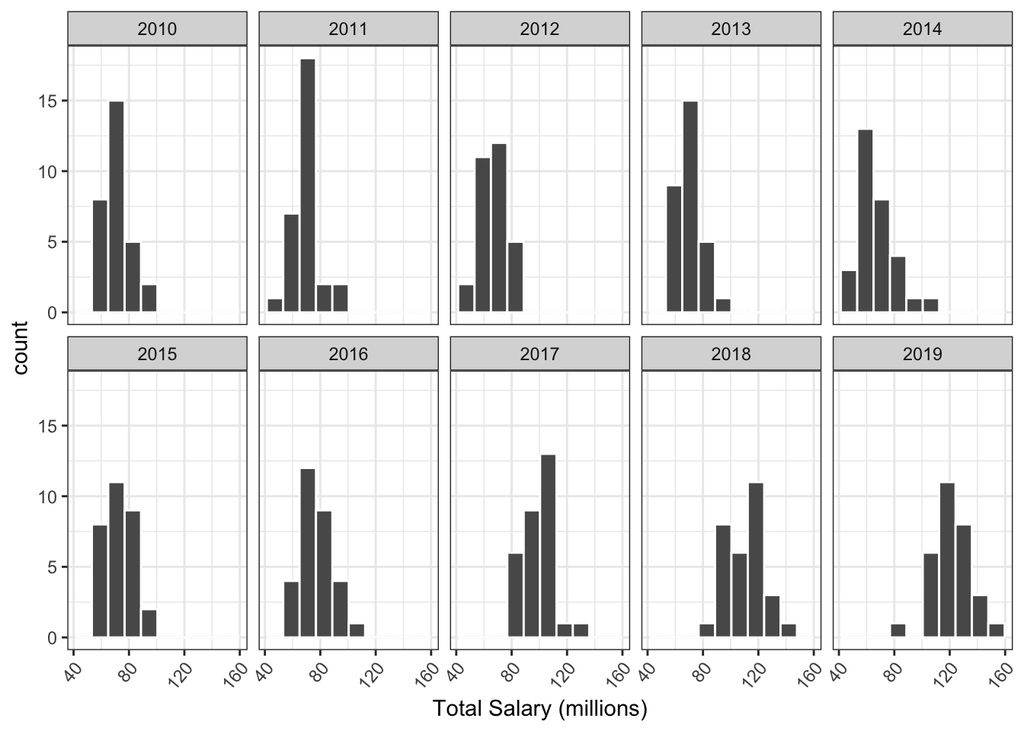

```r
nba %>% ggplot(aes(total_salaries / 1000000)) + geom_histogram(bins=10, color='white') + facet_wrap(~season, nrow=2) + theme_bw() +  theme(axis.text.x = element_text(angle=50, hjust=1)) + xlab('Total Salary (millions)')
```

One major detail that pops out right away: the gradual increase of team salaries over time. We can see the salary distribution starts close to the left end of each plot in earlier seasons, and then gradually shifts toward the higher end. I don’t know about you, but what immediately comes to mind is whether or not this shifting is merely due to inflation, or an actual shift to higher salaries over time. Since adjusting for inflation isn’t challenging, I decide to make this adjustment for a more robust analysis. Note that when adjusting salaries, you need to pick a base year to adjust all salaries back to (or forward to) using the Consumer Price Index (CPI), which is availble [here](https://www.usinflationcalculator.com/inflation/consumer-price-index-and-annual-percent-changes-from-1913-to-2008/). I share all of my code for this adjustment below if you’re curious.

```r
#' @tital Adjust Income
#' @description converts a given vector of salaries for a given year into 2010 dollars
#' @param salary vector of salaries for the same year
#' @param year_CPI is a double that represents the average Consumer Price Index for year of salary
#' @output returns the vector of salaries in terms of 2010 dollars
adjust_income <- function(salary, year_CPI) {
  CPI_2010 <- 218.056
  adjusted_salary <- salary * (CPI_2010 / year_CPI)

  return(adjusted_salary)
}
```

```r
#initialize a vector that will hold all of our new adjusted salaries
adjusted_salaries <- c()

#vector of seasons for which we need to adjust their salaries
seasons_to_adjust <- 2011:2019

#since we aren't adjusting 2010 since we are considering that our base
# in this analysis, we need to add these values to our adjusted salaries
# because we will be adding this as a feature to our dataframe
salaries_2010 <- nba[nba['season'] == 2010, ][['total_salaries']]
adjusted_salaries <- c(adjusted_salaries, salaries_2010)

# initialize a vector that holds average yearly CPI values from website linked above
# for the years 2011-2019
yearly_CPI <- c(224.939, 229.594, 232.957, 236.736, 237.017, 240.007, 245.120, 251.107, 255.657)

#now lets adjust all the other seasons down to our base dollars
for (i in 1:length(seasons_to_adjust)) {
  this_season <- nba[nba['season'] == seasons_to_adjust[i], ]
  this_season_salaries <- this_season[['total_salaries']]
  adjusted_salaries <- c(adjusted_salaries, adjust_income(this_season_salaries, yearly_CPI[i]))
}

#add feature to nba dataframe
nba['adjusted_salaries'] <- adjusted_salaries
```

We can see in the plot below that our adjustment worked - the distribution of adjusted salaries (in red) moves further to the left as time progresses away from the 2009-2010 season.

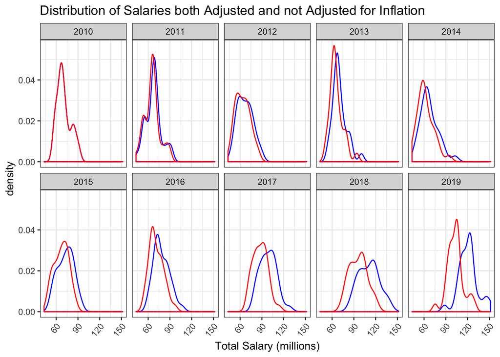

```r
nba %>% ggplot(aes(total_salaries / 1000000)) + geom_density(color='blue') + geom_density(aes(adjusted_salaries / 1000000), color='red') + facet_wrap(~season, nrow=2) + theme_bw() +  theme(axis.text.x = element_text(angle=50, hjust=1)) + xlab('Total Salary (millions)') + labs(title='Distribution of Salaries both Adjusted and not Adjusted for Inflation')
```

Wonderful! I won’t show you this part, but I actually explored the distribution of all my features. It’s just good to become familiar with your data and how it varies for each feature.

Okay, I think I’m ready to start exploring my hypothesis questions. For your convenience I replicate them here:

1. Do teams with high salaries tend to win more games?
2. Do teams with younger, less experiences players tend to have lower salaries?
3. How have team salaries changed over the last ten seasons? Very rapidly? Remained somewhat constant? Or decreased?

I’ll start with the first one and go in order.

##### Salaries and Games Won

My first question: Do teams with higher salaries tend to win more games?

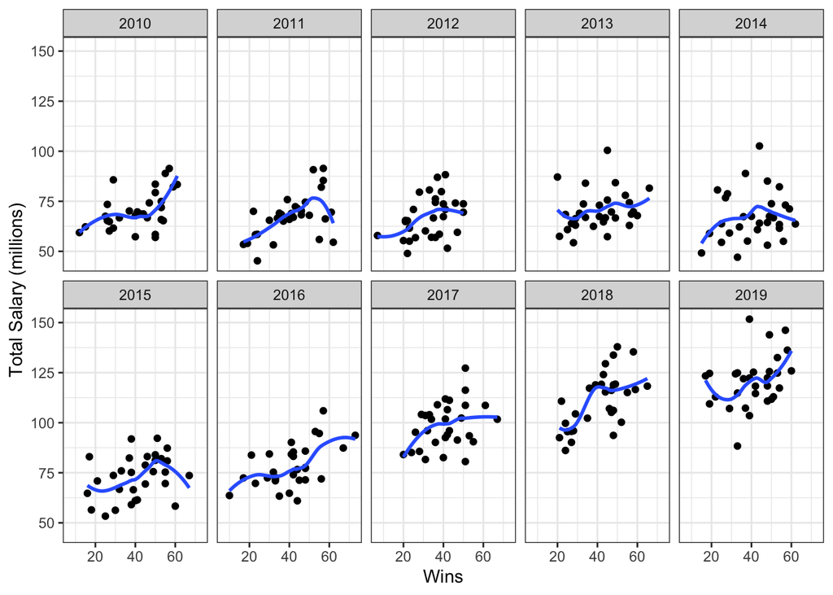

```r
nba %>% ggplot(aes(x=wins, y=total_salaries / 1000000)) + geom_point()  + facet_wrap(~season, nrow=2) + theme_bw() + ylab('Total Salary (millions)') + xlab('Wins') + geom_smooth(method='loess', se=FALSE, formula=y~x)
```

Notice the blue line on each plot. This is called a loess curve or [loess regression](https://blogs.sas.com/content/iml/2016/10/17/what-is-loess-regression.html). I’m normally used to seeing a linear regression line on scatterplots, but loess regression can show more localized trends in data using a nonparametric technique. Without the curve, we can somewhat see a general positive correlation between the variables but it’s not as obvious, so I was advised to explore what a loess curve could show. Overall, looking at this visualization, we can infer there is a positive trend between a team’s salary and games won, especially in more recent seasons.

Let’s move on to my second question.

##### Salaries and Experience

My second question: Do teams with younger, less experienced players tend to have lower salaries?

I expect to see a correlation between experience and salaries because I usually see older, more seasoned NBA players getting paid the most. To answer this question I will need to access total team experience and total salary features. Check out the scatterplot below.

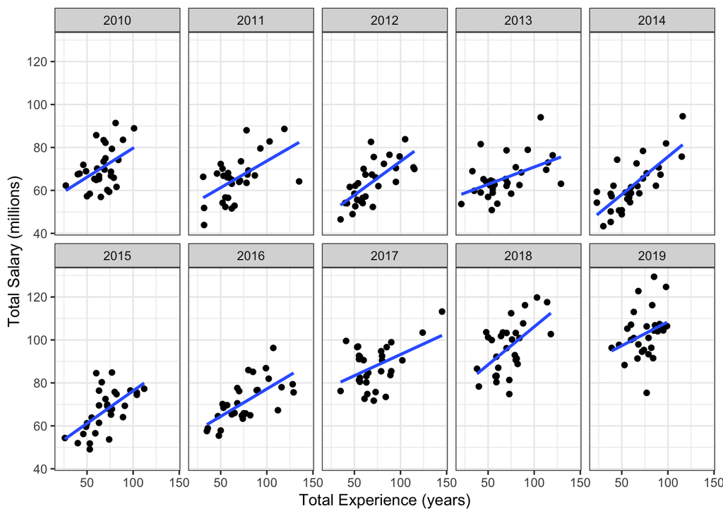

```r
nba %>% ggplot(aes(x=total_experience, y=adjusted_salaries / 1000000)) + geom_point()  + facet_wrap(~season, nrow=2) + theme_bw() + ylab('Total Salary (millions)') + xlab('Total Experience (years)') + geom_smooth(method='lm', se=FALSE)
```

I decided to stick to linear regression for this plot because a linear relationship between these variables is much more obvious. It’s easy to calculate the correlation coefficient ($R^{2}$) for each plot to see just how strong the correlation is between them. Check out my code and the coefficients below.

```r
#' @title Seasonal R_squared
#' @description given two different feature labels, computes the correlation coefficient for all seasons between the years 2010-2019
#' @param y_label is the label of the feature on the y_axis
#' @param x_label is the label of the feautre on the x_axis
#' @output vector of correlation coefficients between labels for seasons 2010-2019
seasonal_rsquared = function(y_label, x_label) {
  #build a sequence that will help us navigate the dataframe by season
  season_starts <- seq(1, 300, 30)

  #initialize a vector to hold all ten season r_squared values
  r_squares <- c()

  #compute and collect seasonal r_squared values
  for (i in season_starts) {
    r_square <- summary(lm(nba[y_label][i:(i+29), ]~nba[x_label][i:(i+29), ]))$r.squared
    r_squares <- c(r_squares, r_square)
  }

  return(r_squares)
}
```

```r
#lets call the function we created above to compute our seasonal r_squared values
r_squares <- seasonal_rsquared('adjusted_salaries', 'total_experience')

#lets build a dataframe to hold the correlation coefficients for each season
seasons <- 2010:2019
r_squared <- data.frame(seasons, r_squares)
colnames(r_squared) <- c('season', 'r_square')
r_squared
```

```
##    season  r_square
## 1    2010 0.2009313
## 2    2011 0.3119247
## 3    2012 0.4903877
## 4    2013 0.2316525
## 5    2014 0.5758988
## 6    2015 0.3641683
## 7    2016 0.4355331
## 8    2017 0.2083069
## 9    2018 0.3126207
## 10   2019 0.0987323
```

I can see that some seasons show a more tight correlation between team experience and total salary, but overall I can infer that yes, less experienced teams tend to have a lower team salary. I can also infer that teams with more experienced players tend to have a higher total salary.

Time to move on to my last hypothesis question.

##### Change in Salaries

My last question: How have team salaries changed over the last ten seasons? Have they remained relatively constant? If they have changed, how rapidly?

To answer this, lets look at line plot for each team showing how team salaries have changed througout the last ten seasons.

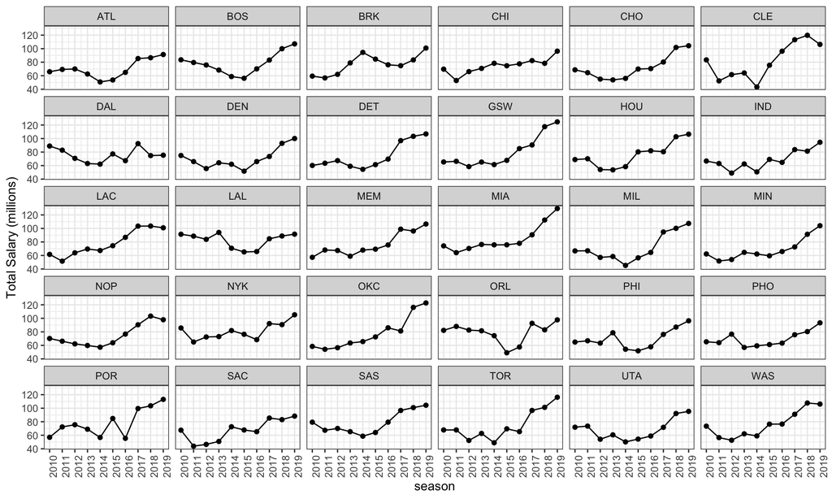

```r
nba %>% ggplot(aes(x=season, y=adjusted_salaries / 1000000)) + geom_line() + geom_point(aes(x=season, y=adjusted_salaries/ 1000000)) + facet_wrap(~team) + theme_bw() + theme(axis.text.x = element_text(angle = 90)) + ylab('Total Salary (millions)') + scale_x_continuous(breaks=2010:2019)
```

Interesting trends…

I can definitely say that salaries have not remained constant. I can see that in the earlier seasons (2010-2016) there are some weird up and down trends for all teams. But, aside from maybe a couple teams, salaries seem to increase at a much faster rate beyond the 2015-2016 season. What I love most about the exploration stage of the data science lifecycle is that when I see a common, sudden trend in data you have to look for possible historical context. Sure enough, there was a salary cap change that occurred around the 2016-2017 season that allowed teams to spend more money on players. Read [here](https://en.wikipedia.org/wiki/NBA_salary_cap) for more info on salary caps for the NBA if you’re interested! Now back to my hypothesis question. I would say that based on the plot above, salaries have generally increased over time, with a more drastic increase happening beyond the 2015-2016 season.

I can’t believe the exploration portion is already over. I did much more exploring than what I’m showing you here, but my focus was to show you how I go about answering hypothesis questions using informative visualizations.

Alright, it’s time for the reporting aspect of the data science lifecycle. This “blog” post is essentially my report, but there is also another final deliverable that I mentioned at the beginning - publishing a web app visualization using R’s [Shiny App](https://shiny.rstudio.com/). I cover this in the reporting section that follows:)

#### Report

If you’ve ever worked with building Graphical User Interfaces (GUIs), then you’ll absolutely love R’s Shiny App. Shiny App is a package in R that helps you build an interactive visualization, meaning someone viewing your visualization can chose what data they want to see and add/remove any additional aesthetics to the plot. I won’t go into too much detail about Shiny App itself, but [here’s](https://vimeo.com/131218530) a video that does a good job at breaking down the main structure needed for a shiny app. If you’ve never worked with building GUIs - no worries - watch the video linked above and follow the rest of the reporting section to see how I go about building my shiny apps.

When thinking about an iteractive visualization, it’s important to identify what you consider as “inputs” and “outputs”. You need to decide how a user can interact with your visualization - drop down menu to choose data? buttons to add additional lines to plot? checkboxes to add or remove aesthetics like medians and averages? Once you understand the general layout, it’s easy to target your inputs (whatever a user can control) and your outputs (plot change based on a user’s input). I’ll show you with my own code.

I’ll start with my most basic shiny app. I want to make an interactive line plot that shows where a specific team’s salary lies each season, relative to the teams with the lowest salary & the highest salary for each season. My input is going to be a drop down menu where the user can select which team they want to look at. The output will be a line plot over ten seasons depicting how a user-selected team fares in terms of the lowest & highest paid teams.

Similar to how I started with extracting a single column and cleaning it for a single team in the cleaning stage, I’m going to do the same here. I pick Atlanta as an example and build the static plot I want. From there I’m able to generalize out for any team selected by a user. See my code for the single static plot:

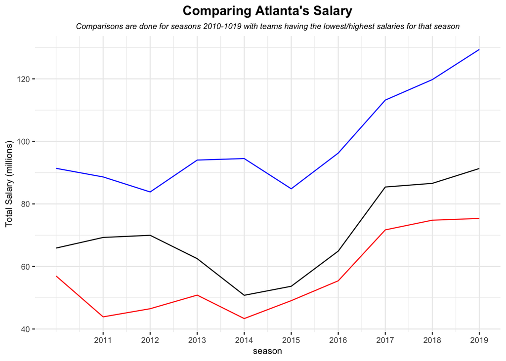

```r
### Building basic shiny app plot for Atlanta only

#variable to hold team name for customized plotting
team_name = 'Atlanta'

#grab rows for Atlanta
team = nba[nba['team'] == 'ATL', ]

#create two dataframes, one with the minimum salaries for each season and other max salaries
min_by_season = nba %>% group_by(season) %>% summarise('min'=min(adjusted_salaries))
max_by_season = nba %>% group_by(season) %>% summarise('max'=max(adjusted_salaries))

#now build customized line plot
ggplot() + geom_line(data=team, aes(x=season, y=adjusted_salaries / 1000000)) +
  geom_line(data=min_by_season, aes(x=season, y=min / 1000000), color='red') +
  theme_bw() +
  ylab('Total Salary (millions)')  +
  geom_line(data=max_by_season, aes(x=season, y=max / 1000000), color='blue') +
  theme_bw() +
  ylab('Total Salary (millions)') +
  scale_x_continuous(breaks=2011:2019) +
  labs(title=paste0('Comparing ', team_name, "'s Salary"), subtitle="Comparisons are done for seasons 2010-1019 with teams having the lowest/highest salaries for that season") +
  theme(plot.title = element_text(hjust = 0.5, size=13, face='bold'), plot.subtitle=element_text(size=8, hjust=0.5, face='italic'), panel.border=element_blank(),
        axis.text=element_text(size=8), axis.title=element_text(size=9))
```

Looks beautiful! I think the only thing missing are labels. Let’s add them in.

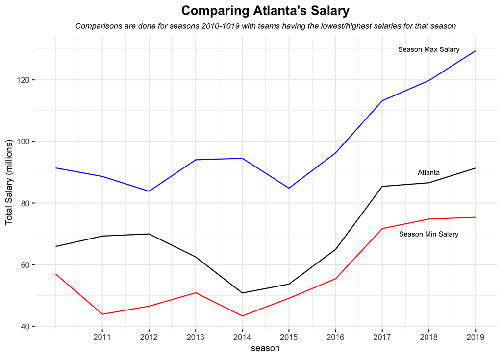

```r
#now build customized line plot with labels
ggplot() + geom_line(data=team, aes(x=season, y=adjusted_salaries / 1000000)) +
  geom_line(data=min_by_season, aes(x=season, y=min / 1000000), color='red') +
  theme_bw() +
  ylab('Total Salary (millions)')  +
  geom_line(data=max_by_season, aes(x=season, y=max / 1000000), color='blue') +
  theme_bw() +
  ylab('Total Salary (millions)') +
  scale_x_continuous(breaks=2011:2019) +
  labs(title=paste0('Comparing ', team_name, "'s Salary"), subtitle="Comparisons are done for seasons 2010-1019 with teams having the lowest/highest salaries for that season") +
  theme(plot.title = element_text(hjust = 0.5, size=13, face='bold'), plot.subtitle=element_text(size=8, hjust=0.5, face='italic'), panel.border=element_blank(),
        axis.text=element_text(size=8), axis.title=element_text(size=9)) +
  geom_text(aes(x = 2018, y = 130, label = "Season Max Salary"), size=2.5) +
  geom_text(aes(x = 2018, y = 90, label = team_name), size=2.5) +
  geom_text(aes(x = 2018, y = 70, label = "Season Min Salary"), size=2.5)
```

Perfect! What’s great about doing one static plot for practice before coding your shiny app with an R script is that I can now identify how to customize for a user’s input. Look at the following two lines from the code chunk above that generated the unlabeled plot:

```r
#variable to hold team name for customized plotting
team_name = 'Atlanta'

#grab rows for Atlanta
team = nba[nba['team'] == 'ATL', ]
```

Whenever a user selects a certain team, I can take this input and replace where you see ‘ATL’ with it. I can also build a function in my shiny app that will take care of both team_name & coordinates dictating where to place the labels. Check out my final published shiny app [here](https://jenny-projects.shinyapps.io/NBA-lineplot/) and play around with the drop down menu!

I’ll move on to another shiny app idea that isn’t as basic, but rather one where the user has more opportunity to add/remove certain aesthetics.

[figure not shown]

```r
#lets consider the first season
season = 2010
this_season = nba[nba['season'] == season, ]

#need stats for adjusted salaries
stats = summary(this_season[['adjusted_salaries']]) / 1000000
mean_salary = stats[4]
median_salary = stats[3]
first_quartile = stats[2]
third_quartile = stats[5]

#lets plot
this_season %>% ggplot(aes(x=team, y=sort(adjusted_salaries / 1000000, decreasing=FALSE))) +
  geom_bar(stat='identity') +
  geom_hline(yintercept = mean_salary, color='blue', size=1) +
  geom_hline(yintercept= median_salary, color='red', size=1) +
  geom_hline(yintercept = first_quartile, linetype='dashed', size=1) +
  geom_hline(yintercept = third_quartile, linetype='dashed', size=1) +
  coord_flip() +
  ylab('Team Salaries (millions)') +
  labs(title='NBA Teams Ranked by Salary', subtitle='Salaries for 2010 season') +
  theme_bw() +
  theme(plot.title = element_text(hjust = 0.5, size=13, face='bold'), plot.subtitle=element_text(size=8, hjust=0.5, face='italic'), panel.border=element_blank(),
        axis.text=element_text(size=8), axis.title=element_text(size=9))
```

It looks beautiful!! One thing I notice is that the bars extend out pretty far from the baseline (0). How about adding a slider where the user can pick the baseline for the bars? Let’s play around with the barchart to see if we can change the baseline to 50 million instead of 0.

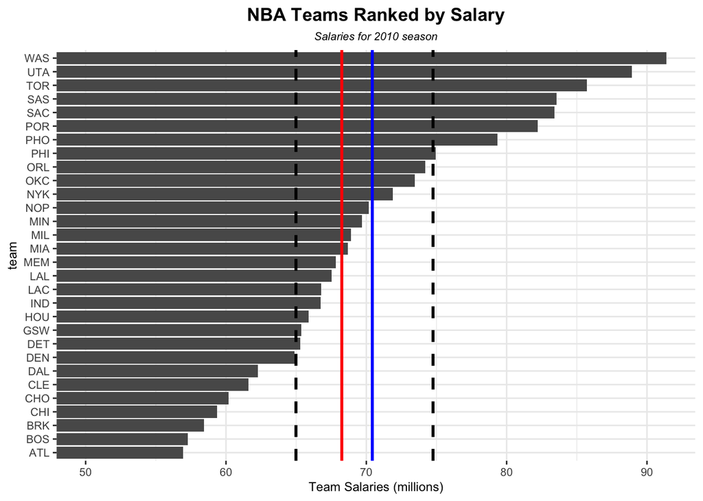

```r
#need stats for adjusted salaries
stats = summary(this_season[['adjusted_salaries']]) / 1000000
mean_salary = stats[4]
median_salary = stats[3]
first_quartile = stats[2]
third_quartile = stats[5]

#lets plot
this_season %>% ggplot(aes(x=team, y=sort(adjusted_salaries / 1000000, decreasing=FALSE))) +
  geom_bar(stat='identity') +
  geom_hline(yintercept = mean_salary, color='blue', size=1) +
  geom_hline(yintercept= median_salary, color='red', size=1) +
  geom_hline(yintercept = first_quartile, linetype='dashed', size=1) +
  geom_hline(yintercept = third_quartile, linetype='dashed', size=1) +
  coord_flip(ylim = c(50, max(this_season[['adjusted_salaries']] / 1000000))) +
  ylab('Team Salaries (millions)') +
  labs(title='NBA Teams Ranked by Salary', subtitle='Salaries for 2010 season') +
  theme_bw() +
  theme(plot.title = element_text(hjust = 0.5, size=13, face='bold'), plot.subtitle=element_text(size=8, hjust=0.5, face='italic'), panel.border=element_blank(),
        axis.text=element_text(size=8), axis.title=element_text(size=9))
```

Nice! Being able to zoom in gives the user a closer look at the length of the bars relative to one another. It’s hard to compare when the baseline is so far away. If you’re intersted in playing around with the final product, its published [here](https://jenny-projects.shinyapps.io/NBA-barplot/)!

#### Summary

I hope that this tutorial/blog post motivates you to go after your own passions project by providing a lot of explanation and code. I know that I would have done something like this a lot sooner if I had a detailed example like this floating around on the internet somewhere. This was actually my motivation - to show other undergraduate students that there is so much you can do with data once you’ve taken a couple basic classes. You might not be taught everything - like scraping data from the web - but it’s up to you to go deeper and expand your skillset.

School provides you with basic tools and skills, but in a post-graduation world you’re going to need to show that you can build on those basic skills. Remember this - graduating from UC Berkeley with just a couple data science classes means that you’re more highly skilled than most students graduating from other schools around the world. Own this opportunity and show the world what you’re made of. Good luck!